# Inspecting C:N effects on CUE and steady states

## Summary

What is the effect of changing C:N of litter input on carbon use efficiency CUE and on predicted steady states?

Here, we vary the C:N ratio of inputs and plot the resulting steady state of stocks and other variables.

## Model versions

- SESAM4a: soil enzyme steady allocation model with microbial turnover rate by predation increases linearly with microbial biomass.

### Setup parameters and drivers

Mass units are $gC/m^2$, $gN/m^2$ or $gP/m^2$. Time unit is $yr$.

```r
require(sesam)

parms0 <- list(
  cnB = 8.3       ##<< Cleveland07, grassland
  , cnBW = 8.4    ##<< C/N ratio of cell material that go to RC  (cell walls) NRSOM Tipping 16
  , cnE = 3.2     # Sterner02: Protein (Fig. 2.2.), high N investment (low P)
  , cnIR = 4.5     ##<< between micr and enzyme signal
  , cnIL = 30      ##<< N litter OM
  , kmN = 0.3*0.01*365  ##<< /yr enzyme turnover 1% turning over each day
  , kNB = 0.8      ##<< amount of recycling enzyme turnover by biomass (added to uptake instead of RC )
  , kR = 1/(50)    ##<< 1/(x years)
  , kL = 1/(1)     ##<< 1/(x years)
  , aE = 0.001*365 ##<< C biomass allocated to enzymes gC/day /microbial biomass
  #, km = 0.3       ##<< enzyme half-saturation constant
  , m = 0.02*365   ##<< maintenance respiration rate   gC/day /microbial biomass
  , tau = 1/60*365 ##<< biomass turnover rate (12 days)
  , eps = 0.5      ##<< carbon use efficiency
  , epsPred = 0.3  ##<< carbon use efficiency of microbial tvr (predators respire)
  , iR = 0         ##<< input modelled explicitely
  , iL = 300       ##<< g/m2 input per year (half NPP)
  , plantNUp = 0   ##<< plant N uptake balancing N inputs
  , useFixedAlloc = FALSE    ##<< set to true to use fixed enzyme allocation (alpha = 0.5)
  , kIPlant = 10.57 #0.0289652*365         ##<< plant uptake iP I
  , iB = 0.38 * 10.57 #0.0110068*365   ##<< immobilization flux iB I
  , iI = 0         ##<< input of mineral N
  , l = 0.96 #0.00262647*365       ##<< leaching rate of mineralN l I
  , nu = 0.9       ##<< microbial N use efficiency
  , isEnzymeMassFlux = TRUE  ##<< steady state BC solution accounts for enyzme mass fluxes
  , nuP = 0.3      ##<< microbial uptake of depolymerized P, (1-nuP) is mineralized
  , cpE = 100     ##<< Sterner02, protein with no P
  , cpB = 47.3    ##<< Cleveland07, grassland
  , cpBW = 61     ##<< NRSOM Tipping16
  , cpIR = 61
  , cpIL = 919    ##<< NPSOM Tipping 16
  , iBP = 0.38 * 10.57 # start with same as N
  , cW = 0.8 # proportion of cell wall within microbial biomass
  , B0 = 0  # minimal biomass, below which predation rate is zero
  , tauP = 0.1 # slope of predation rate with biomass
  , nuP = 0.01 # DOP almost all mineralized before taken up
)
parms0 <- within(parms0,{
  lP <- l       # leaching rate of inorganic P equals that of N
  kiPlant <- 0  # no plant uptake
  kIPPlant <- kIPlant  # plant uptake rate of P equals that of N
  iIP <- l      # assume no P inputs compensate for leaching
})
# assure no P-limitation
parms0 <- within(parms0,{
  plantNUpAbs <- iL/cnIL
  lP <- kIPlant <- 0    # no leaching of P
  iBP <- 1e6            # no limit of P immobilization flux
})
# neglect influence of inorganic pools (keep them at fixed initial values)
parms0$isFixedI <- TRUE
```

For simplicity model drivers are currently prescibed as constant parameters.

```r
drivers <- list(
  iR = 0           ##<< input of residue litter
  , iL = 400       ##<< input of labile litter
  , cnIR = 7       ##<< C/N ratio of the residue litter input
  , cnIL = 30      ##<< C/N ratio of labile litter input
  , cpIR = 40      ##<< C/P ratio of the residue litter input
  , cpIL = 919     ##<< C/P ratio of the labile litter input, NPSOM Tipping16
  , iI = 0         ##<< input of mineral N
  , iIP = 0        ##<< input of labile mineral P
)
parms0 <- c(parms0[setdiff(names(parms0),names(drivers))], drivers)
```

The initial pools must be specified.

```r
x0 <- c( #aE = 0.001*365
  BC = 17                    ##<< microbial biomass in C units
  , RC = 1100                ##<< C residue OM
  , RN = 1100/parms0$cnIR   ##<< N residue OM
  , RP = 1100/parms0$cpIR   ##<< P residue OM
  , LC = 100                 ##<< C litter OM
  , LN = 100/parms0$cnIL    ##<< N litter OM
  , LP = 100/parms0$cpIL    ##<< P litter OM
  , I =  0.1               ##<< inorganic N pool
  , IP =  0.01              ##<< inorganic P pool
  , alpha = 0.5             ##<< microbial community partitioning [0,1]
)
```

# Run to steady state

The first simulation runs to steady state for given parameters.

```r
  times <- c(seq(0,500, length.out = 101), 2000)
  res <- res1 <- as.data.frame(lsoda( x0, times, derivSesam4a, parms = parms0))
  xE <-  unlist(tail(res,1)) # final state
  x0S <- xE[1 + seq_along(x0)]
```

# CN scenarios

Starting from this steady state, several scenarios of changing C:N ratio of litter inputs are simulated. This means for same C input, varying the N inputs.

While the original run was C-limited, perform a run that is N-limited by increasing the C:N ratio of litter input.

```r
parms <- within(parms0, cnIL <- 80)
times <- c(seq(0,500, length.out = 101), 2000)
res <- as.data.frame(lsoda( x0S, times, derivSesam4a, parms = parms))
xE <- unlist(tail(res,1)) # final state
```

Next, inspect the steady state obtained after a range of C:N litter inputs.

```r
cnILs <- seq(parms0$cnIL, 70, length.out = 21)
times <- c(0, 2000)
xEs <- map_dfr(cnILs, function(cnILi){
  parms <- within(parms0, cnIL <- cnILi)
  res <- as.data.frame(lsoda( x0S, times, derivSesam4a, parms = parms))
  xE <- unlist(tail(res,1)) # final state
  cbind(as.data.frame(t(xE)), cnIL = cnILi)
})
#xEs
```

Plotting steady state against C:N of litter input.

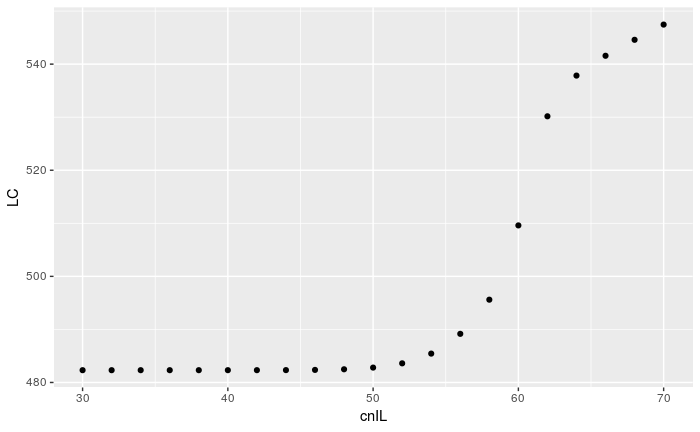

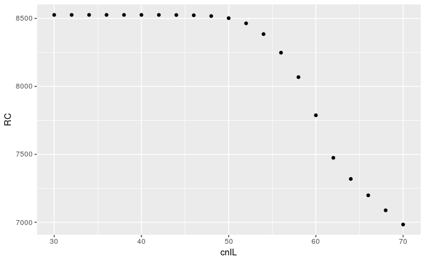

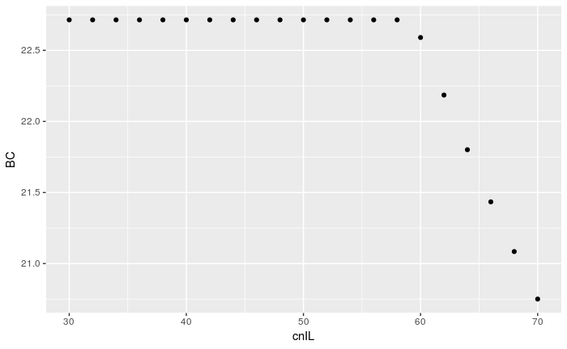

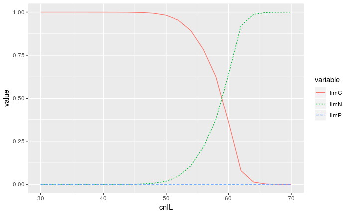

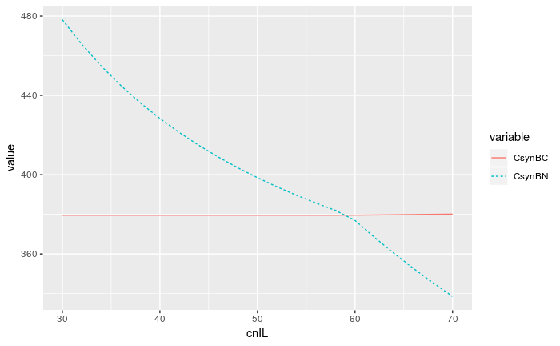

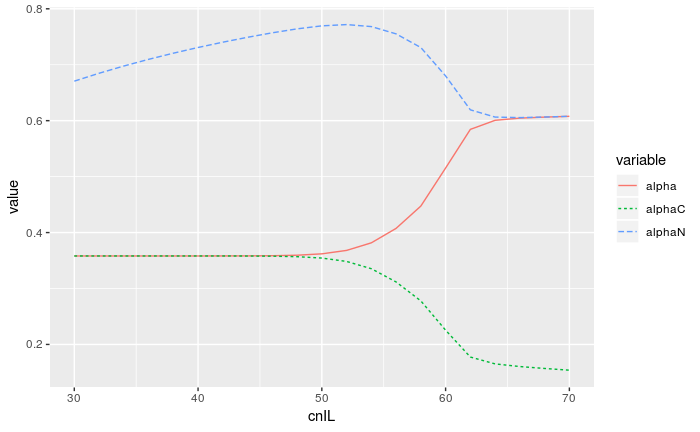

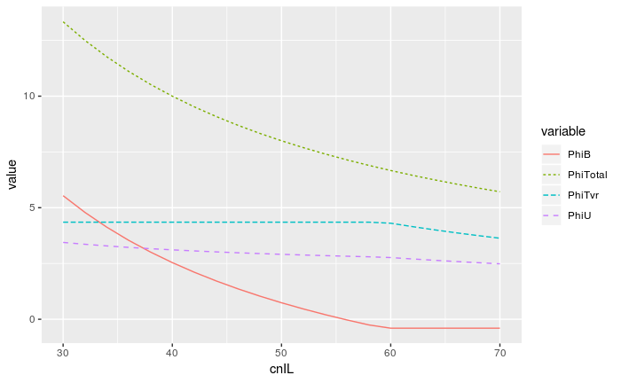

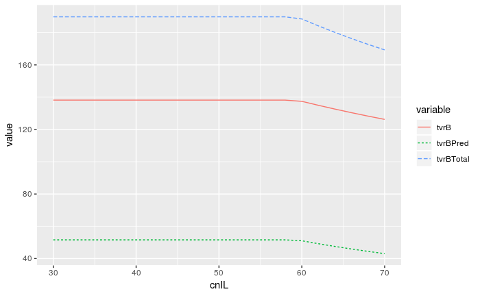

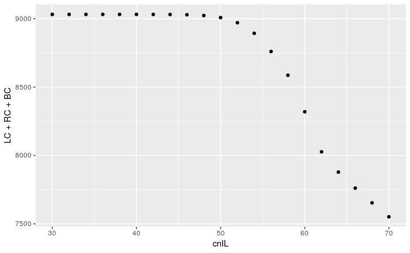

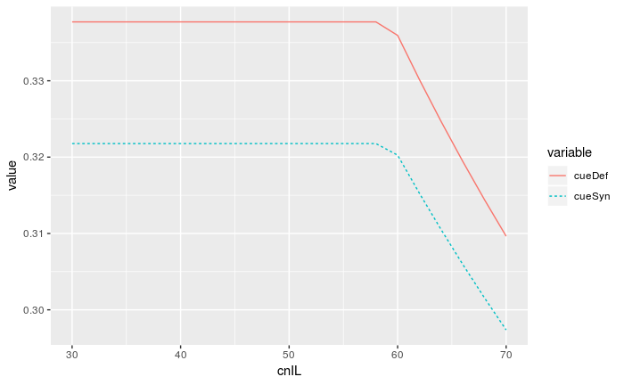

In steady state, all the organic N inputs to the soil will be mineralized, i.e. $\Phi_{Total} = \beta_{iL} i_L$. Immobilization only occurs if the other N mineralization fluxes (during uptake and during turnover) exceed the N litter inputs.

Up to this point where N actually limits microbial growth, stocks do not change. Afterwards they decrease together with microbial biomass stocks and CUE.

Note, also that apparent CUE is lower than the intrinsic catabolic CUE, $\epsilon = 0.5$, due to investments into enzymes and maintenance that decrease the C available for biomass synthesis. Basing CUE on adding microbial biomass synthesis and measured respiration (including respiration by predation), $cue_{Syn}$, yields similar estimates as those based on modeled microbial uptake, $cue_{Def}$.

## DOM and synthesis flux composition

Despite the high C/N ratios of litter, the substrate for microbial synthesis has more nutrients, due to decomposition of N-rich residue, and turnover of microbial biomass and enzymes.

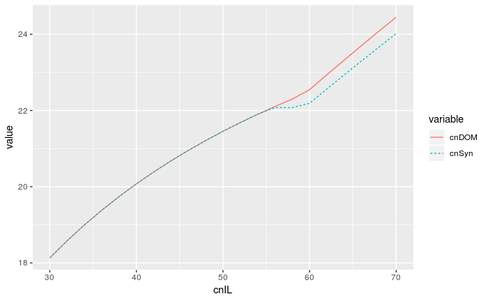

cnDOM is the C:N ratio of the disolved organic matter (DOM), and cnSyn is the C:N ratio of the matter flux used for biosynthesis and mineralization. The latter includes immobilization of nutrients and usage of starved biomass (cryptic) growth.

Unitl a threshold elemental ratio, TER, of about 22, there is mineralization of microbial N uptake from DOM. At DOM C/N ratios of slightly above this value, immobilization of inorganic N kepps the synthesis flux at the co-limitation.

Decomposition of residue OM, $dec_{NR}$ is the largest contribution to synthesis N flux. Direct flux of microbial turnover to DOM, $dec_{NB}$ also contributes substantially, and in the used parameterization also the flux by enzyme production and turnover, $dec_{NE}$. At steady state there is no microbial starvation, $starv_N$, and immobilization of inorganic N, $immo_N$, contributes a small share when organic N is limiting.

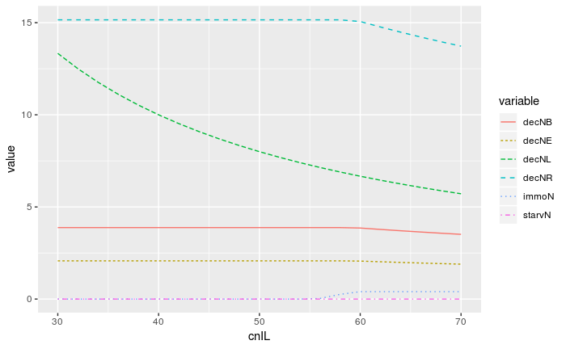